# hw-02

Qihang Yu (S2960448)

2026-10-29

```r
strava_runs <- read_csv("data/strava_runs.csv")
data_5k_10k <- strava_runs %>%
  mutate(
    event = case_when(
      distance..m. > 4998 & distance..m. < 5015  ~ "5k",
      distance..m. > 9998 & distance..m. < 10015 ~ "10k",
      TRUE ~ NA_character_
    )
  ) %>%
  filter(!is.na(event))
```

## Exercise 1

When you fill the missing part, remove the # symbol before running the code chunk and eval=FALSE

```r
data_5k_10k %>%
   filter(gender == "M") %>%
  filter(!is.na(average.heart.rate..bpm.)) %>%
   ggplot(aes(x = average.heart.rate..bpm.)) +
  geom_histogram(bins = 20)

data_5k_10k %>%
  filter(gender == "M") %>%
  summarise(
    mean_hr = mean(average.heart.rate..bpm., na.rm= TRUE),
    median_hr = median(average.heart.rate..bpm., na.rm = TRUE),
    sd_hr = sd(average.heart.rate..bpm., na.rm = TRUE)
  )
```

[output not shown]

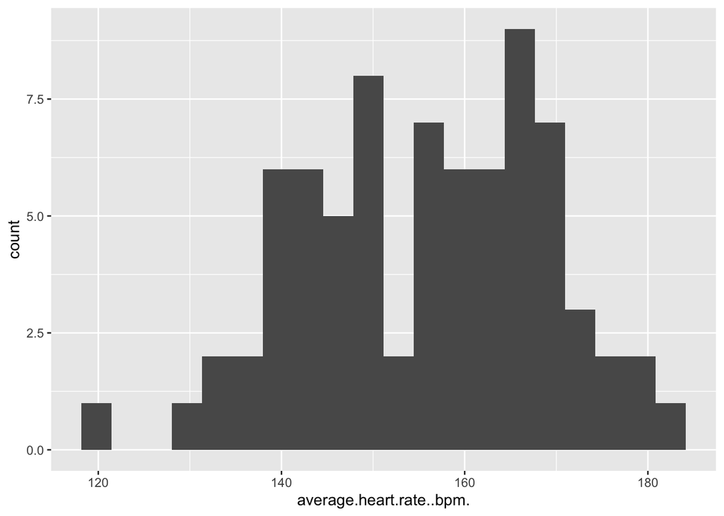

```r
data_5k_10k %>%
  filter(gender == "F") %>%
  filter(!is.na(average.heart.rate..bpm.))%>%
  ggplot(aes(x = average.heart.rate..bpm.)) +
  geom_histogram(bins = 20)
```

[output not shown]

## Exercise 2

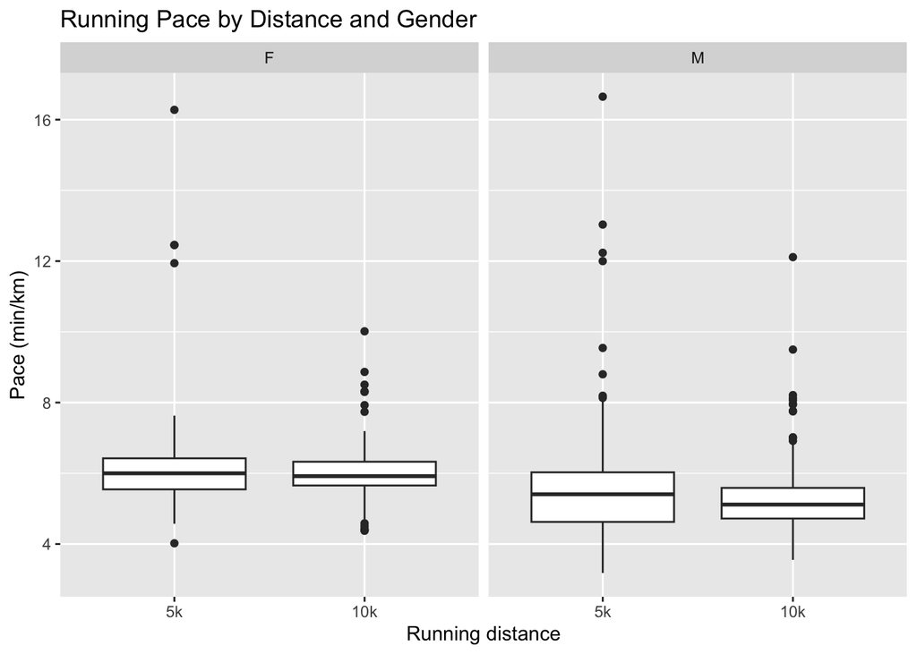

```r
data_5k_10k %>%
  filter(!is.na(gender))%>%
  mutate(
    pace = (elapsed.time..s./60)/
      (distance..m. /1000),
    event = factor(event, level = c("5k","10k"))
  ) %>%
  ggplot(aes(x = event, y = pace))+
  geom_boxplot() +
  facet_wrap(~ gender) +
  labs(
    title = "Running Pace by Distance and Gender",
    x = "Running distance",
    y = "Pace (min/km)"
  )
```

The boxplots compare running pace for 5K and 10K runs by gender. Among female runners, the median pace is similar for the two distances, at around 6 minutes per kilometer. Among male runners, the median pace is lower for 10K than for 5K, suggesting faster running over 10K in the dataset. Both genders show some high-pace outliers, and the 5K runs for male runners appear to have greater variability. In conclusion, the male runners have lower median pace values than female runners in the dataset.

## Exercise 3

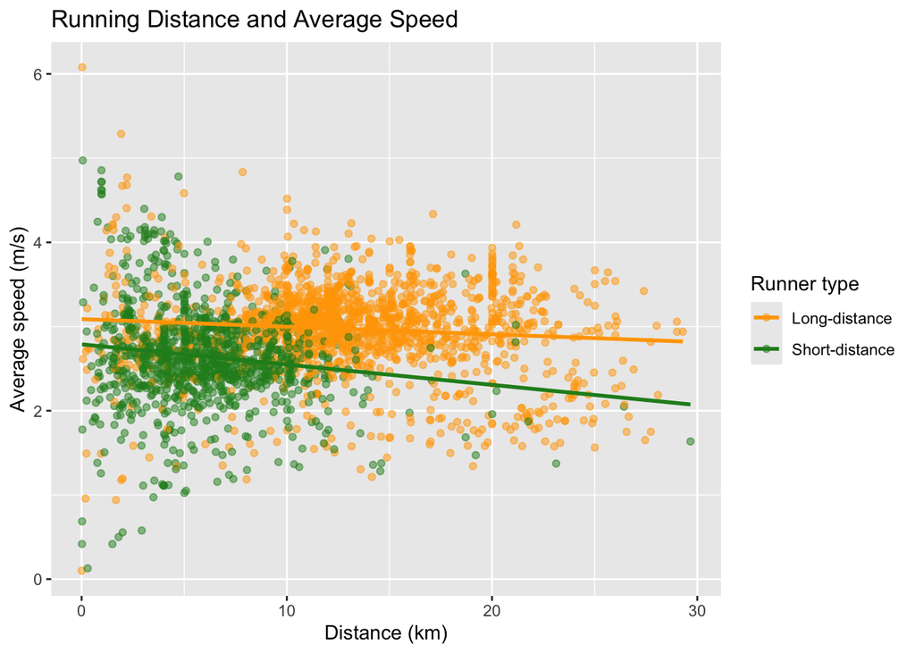

```r
athlete_distance <- strava_runs %>%
  filter(!is.na(distance..m.)) %>%
  group_by(athlete)%>%
  summarise(
    mean_distance = mean(distance..m.)/1000
  ) %>%
  mutate(
    runner_type = case_when(
      mean_distance > 13 ~ "Long-distance",
      mean_distance < 7 ~ "Short-distance",
      TRUE ~ NA_character_
    )
  )

data_speed <- strava_runs%>%
  left_join(
    athlete_distance %>%
      select(athlete,runner_type),
    by = "athlete"
  )%>%
  filter(!is.na(runner_type))%>%
  filter(
    !is.na(distance..m.),
    !is.na(elapsed.time..s.),
    elapsed.time..s.>0
  )%>%
  mutate(
    distance_km = distance..m./1000,
    speed = distance..m./elapsed.time..s.
  )
data_speed %>%
  ggplot(aes(
    x = distance_km,
    y = speed,
    colour= runner_type
  ))+
  geom_point(alpha = 0.5)+
  geom_smooth(method = "lm",se= FALSE)+
  scale_color_manual(
    values = c(
      "Long-distance" = "orange",
      "Short-distance"= "forestgreen"
    )
  )+
  labs(
    title = "Running Distance and Average Speed",
    x = "Distance (km)",
    y = "Average speed (m/s)",
    color = "Runner type"
  )
```

The scatter plot shows the relationship between running distance and average speed for short-distance and long-distance runners. The trend lines suggest a negative relationship between distance speed in both groups, particularly for short-distance runners. The negative trend is weaker for long-distance runners. However, the points are widely scattered and the two groups overlap considerably, indicating substantial variation in speed at similar distances. These results show an association rather than a causal relationship.

## Exercise 4

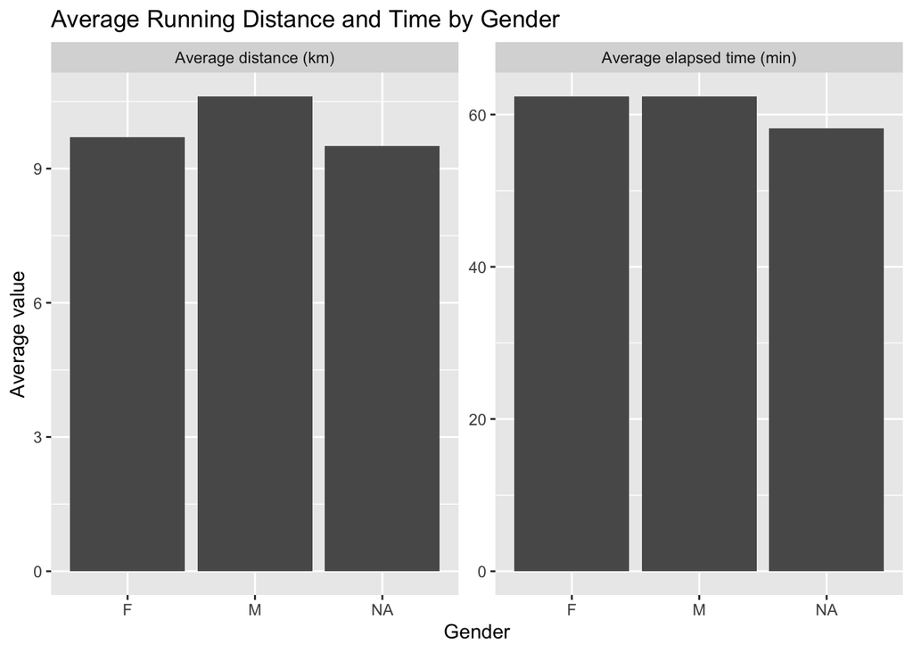

```r
strava_runs%>%
  group_by(gender) %>%
  summarise(
    mean_distance = mean(distance..m.,na.rm = TRUE)/1000,
    mean_time = mean (elapsed.time..s.,na.rm = TRUE)/60
  )%>%
  pivot_longer(
    cols = c(mean_distance, mean_time),
    names_to = "measure",
    values_to = "average"
  ) %>%
  mutate(
    measure = recode(
      measure,
      mean_distance = "Average distance (km)",
      mean_time = "Average elapsed time (min)"
    )
  )%>%
  ggplot(aes(x = gender, y = average))+
  geom_col()+
  facet_wrap(~ measure, scales= "free_y")+
  labs(
    title = "Average Running Distance and Time by Gender",
    x = "Gender",
    y = "Average value"
  )
```

The bar charts compare the mean running distance and mean elapsed time by gender. Male runners have a higher mean running distance than demale runners in this dataset. However, the mean elapsed times for male and female runners are very similar, with females having a silghtly higher mean. These are decriptive comparsions of the recorded runs and do not establish that gendeer causes the difference.